# 003 death

Katie Gostic

11/1/2017

Notes on data formatting from Deborah Wentworth:

- symdur is symptom duration (days) prior to enrollment
- date info is for enrollment date
- fluvac6 and fluvac12 are flu vaccination in last 6 or last 12 months
- anyvac combines values from fluvac6 and fluvac12, whichever was collected for a given patient is reported.
- anyav is use of antivirals at any time
- anydx is any diagnosis in the medical history section
- flutype is subtype: 1=H1N1, 2=H3N2, 3=flu B, 4=PCR negative, 5=Inf A, subtype unknown, and 6=coinfection with multiple strains
- resolved is symptom resolution within 14 days
- country code is the 3 letter code for country of enrollment - think the abbreviations will be obvious

#### Visualize the relationship between age and prob of H1N1 infection

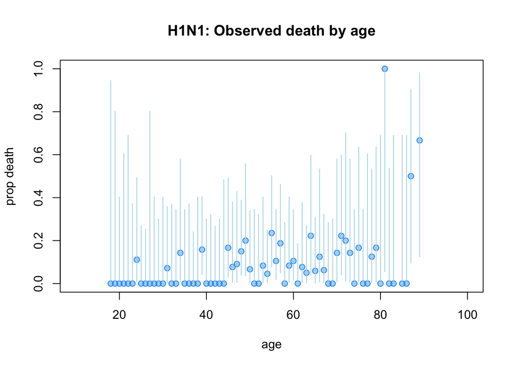

#### Visualize the relationship between age and prob of H3N2 infection

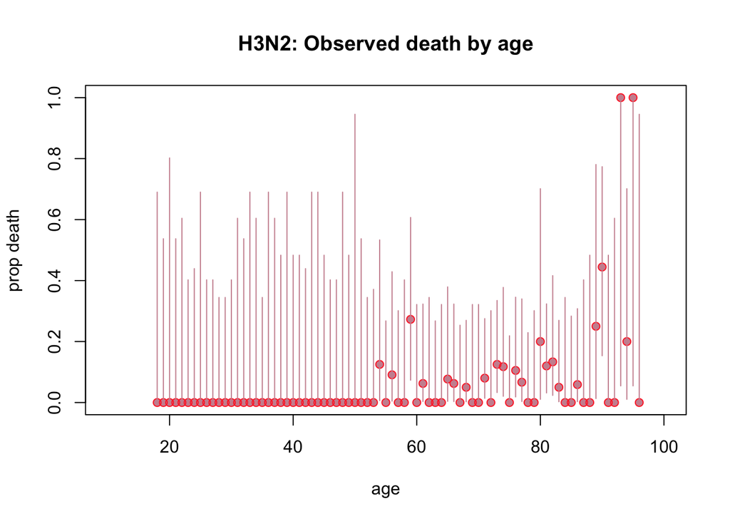